# Udacity_Project_EDA

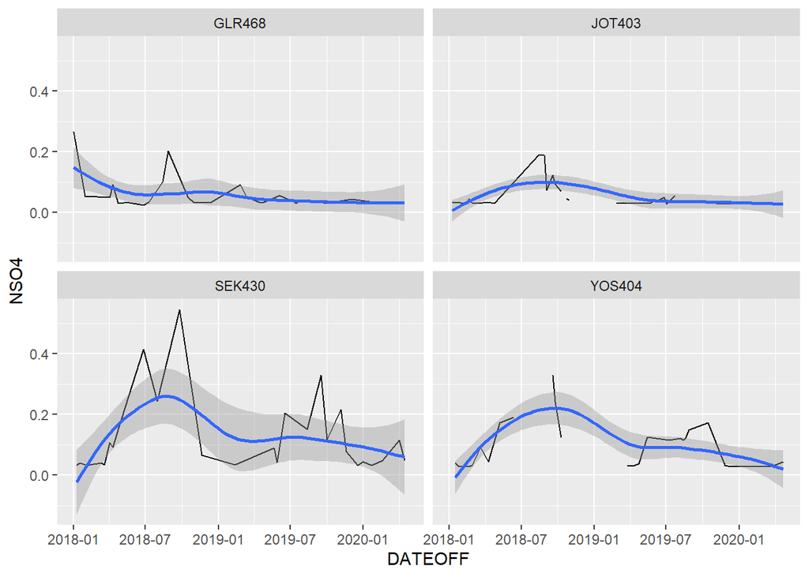

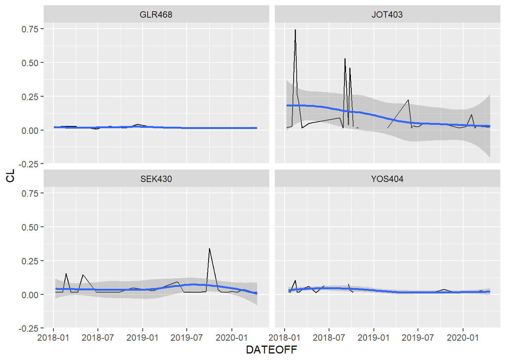

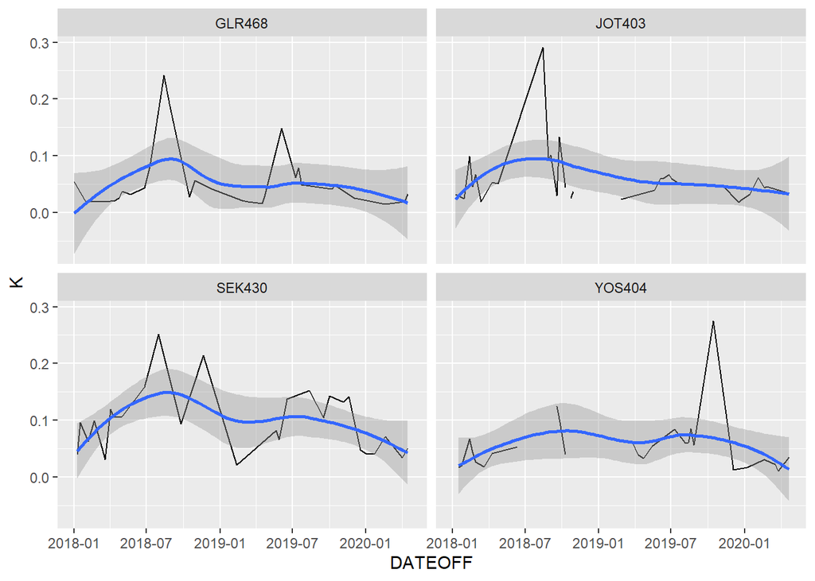

[6 more figures not shown]

A correlation between the Flow Volume and Gaseous measurements does not exist.

```
##
##  Pearson's product-moment correlation
##
## data:  Target_data$FLOW_VOLUME and Target_data$Gaseous
## t = -0.29972, df = 115, p-value = 0.7649
## alternative hypothesis: true correlation is not equal to 0
## 95 percent confidence interval:
##  -0.2084142  0.1543777
## sample estimates:
##         cor
## -0.02793822
```

```
##
##  Pearson's product-moment correlation
##
## data:  Target_data$FLOW_VOLUME and Target_data$Particulate
## t = 2.3884, df = 115, p-value = 0.01855
## alternative hypothesis: true correlation is not equal to 0
## 95 percent confidence interval:
##  0.03733425 0.38378123
## sample estimates:
##       cor
## 0.2173939
```

There appears to be a correlation between Particulate and Gaseous measurements.

```
##
##  Pearson's product-moment correlation
##
## data:  Target_data$Particulate and Target_data$Gaseous
## t = 11.615, df = 115, p-value < 2.2e-16
## alternative hypothesis: true correlation is not equal to 0
## 95 percent confidence interval:
##  0.6383242 0.8084282
## sample estimates:
##       cor
## 0.7347201
```

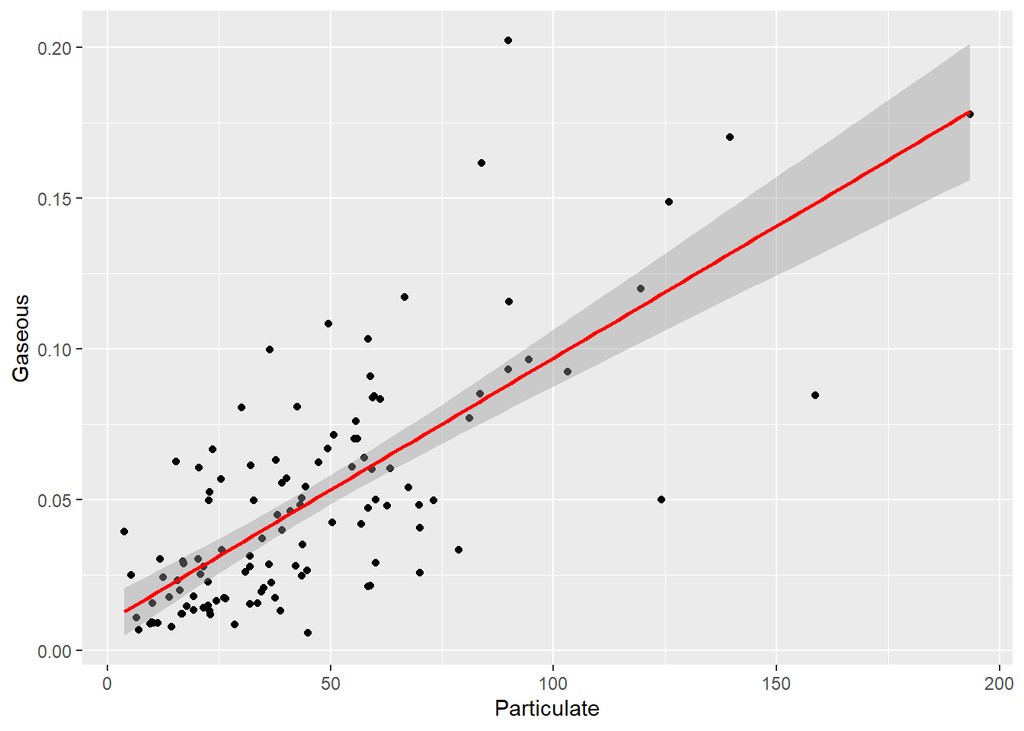

```r
ggplot(aes(x = Particulate, y= Gaseous), data = Target_data) +
  geom_point()+
  geom_smooth(method = 'lm', color = 'red')
```

# Bivariate Analysis

### Talk about some of the relationships you observed in this part of the

investigation. How did the feature(s) of interest vary with other features in  
the dataset?

The majority of the data plots have most of their observations around the 30 m^3 air flow volume. Gaseous pollution (S02) is most prevalent in JOT403 and SEK430. SEK430 has significant concentration of pollutants in all of the graphs. JOT403 and SEK430 have the highest and second highest PPM measurements (worst and second worst air quality) within the United States. The graphs confirm that these locations receive a higher concentration of air pollutant.

### Did you observe any interesting relationships between the other features

(not the main feature(s) of interest)?

SEK402 which averages 20 m^3 air flow volume consistently shows the highest concentration of PM2.2 and gaseous pollution. However, This inconsistency is not explored because the data for SEK402 ends in the 2005.

### What was the strongest relationship you found?

Since the 1990 Clean Air Act states have taken significant steps to reduce emissions of pollution. The graphs explored in this section confirm that states are continuing that effort.

# Multivariate Plots Section

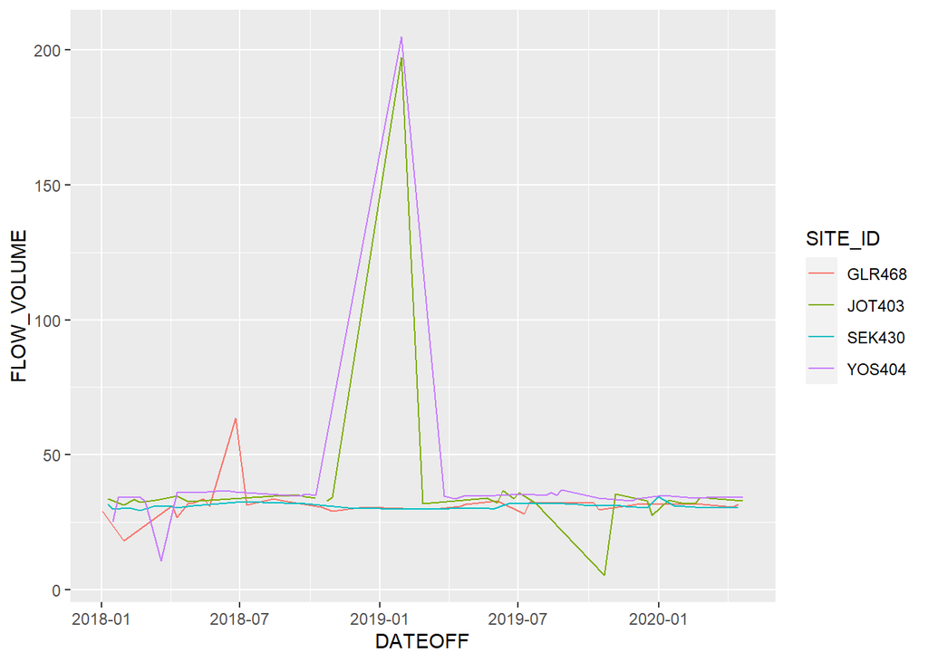

```
##    Min. 1st Qu.  Median    Mean 3rd Qu.    Max.    NA's
##   5.249  30.923  32.503  35.092  34.394 204.912       1
```

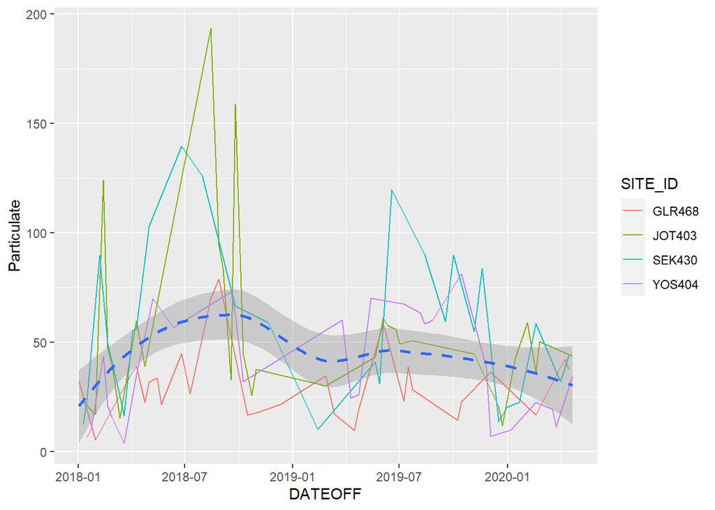

```
##    Min. 1st Qu.  Median    Mean 3rd Qu.    Max.    NA's
##   3.815  22.650  38.751  45.559  59.002 193.390       5
```

```
## No summary function supplied, defaulting to `mean_se()`
```

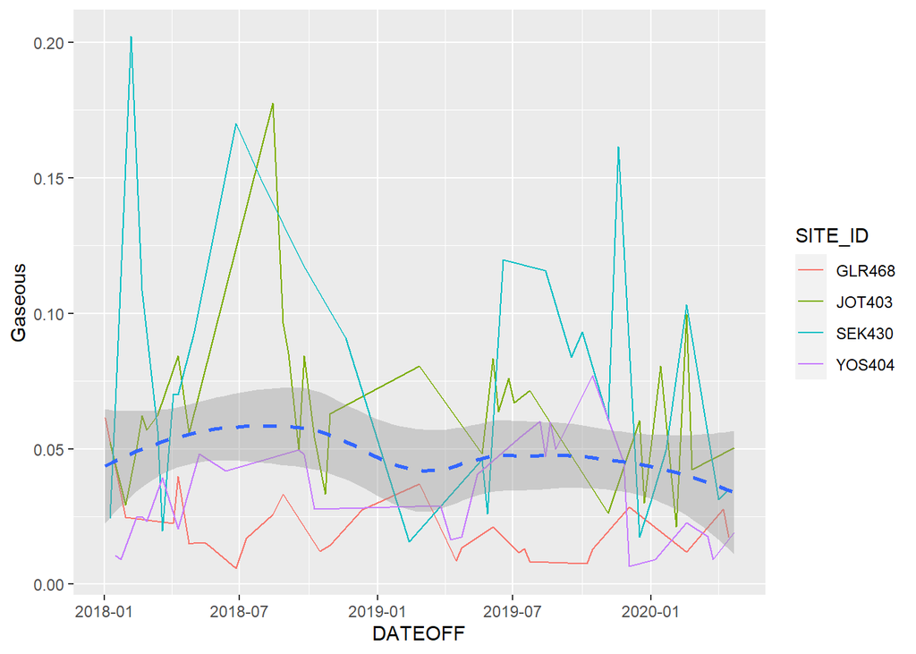

```
##     Min.  1st Qu.   Median     Mean  3rd Qu.     Max.     NA's
## 0.005782 0.020479 0.040650 0.049277 0.063696 0.202223        5
```

# Multivariate Analysis

### Talk about some of the relationships you observed in this part of the

investigation. Were there features that strengthened each other in terms of  
looking at your feature(s) of interest?

When looking at the data Glacier National Park, MT has significantly less gaseous and fine particulate matter than any of the sites located in California. The closest population center to Glacier Park is Columbia falls (population 6000) at 17.5 miles to the South West.

Meanwhile YOS404 168 miles from Sacramento, 193 miles from San Francisco. Joshua Tree (JOT403) is 131 miles from Los Angeles. SEK 430, Ash Mountain, is 60 miles from Fresno and 250 miles from San Francisco. These population centers all have over 500,000 individuals.

### Were there any interesting or surprising interactions between features?

Additionally, the location where higher population centers are close by the level of pollutants are significantly higher.

# Final Plots and Summary

> **Tip**: You’ve done a lot of exploration and have built up an understanding of the structure of and relationships between the variables in your dataset. Here, you will select three plots from all of your previous exploration to present here as a summary of some of your most interesting findings. Make sure that you have refined your selected plots for good titling, axis labels (with units), and good aesthetic choices (e.g. color, transparency). After each plot, make sure you justify why you chose each plot by describing what it shows.

### Plot One

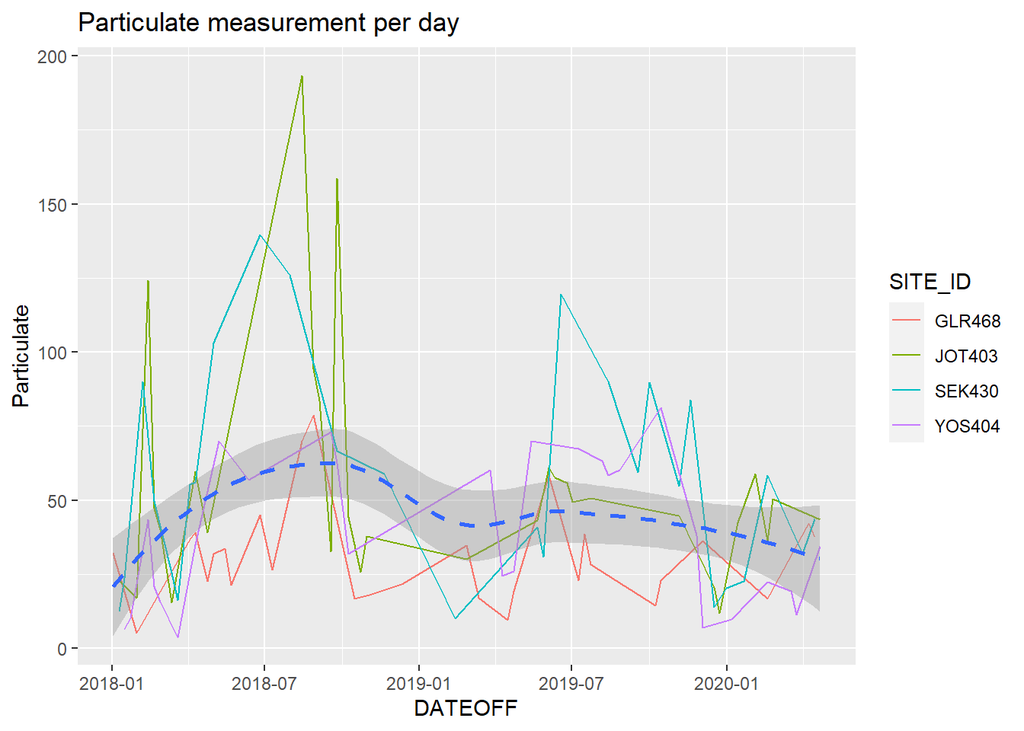

### Description One

This Graph shows the mean of all four sites Particulate matter as a dashed blue line. Observing this graph you can see that GLR468’s data points (orange) are consistently below this dashed line. Conversely the two locations with the worse Air Quality rating, JOT403 and SEK430, are significantly above the dashed blue line.

### Plot Two

```
## No summary function supplied, defaulting to `mean_se()`
```

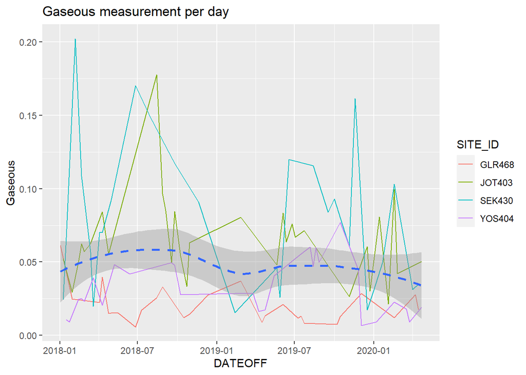

### Description Two

This Graph shows again the mean of all four sites Gaseous pollution as a dashed blue line. Observing this graph you can see that GLR468’s data points (orange) are consistently below this dashed line. Conversely the two locations with the worse Air Quality rating, JOT403 and SEK430, are significantly above the dashed blue line. YOS404 the best rated Air Quality in California also has a significant amount of data points below the dashed blue line.

### Plot Three

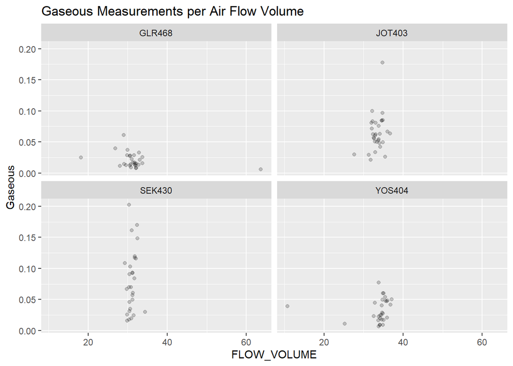

### Description Three

Finally, this graph shows that no four locations averaged about the same ar Flow Volume (between 30-35 m^3). This eliminates the possibility that maybe the air flow volume increase could throw off the data. GLR468 maintains a low weight of gaseous material, a weight lower than JOT403 (site with worse Air Quality rating). SEK430’s graph shows no consistency as the data points range from the top to the bottom of the graph.

# Reflection

The effects of these pollutants on the environment is not explored in this project either. Nor are the potential causes for these high concentrations. New York City, NY has a population of 8.4 million and the closest monitoring location has a rating of 71, significantly lower than JOT403’s 88. Factors that could affect the ratings were not discovered through data. HOwever, Trade Winds, Climatology, volcanic eruptions, geysers, and other environmental factors could explain the discrepencies seen in the Air Quality ratings.

Sources: https://www.epa.gov/cas https://www.epa.gov/castnet/castnet-ozone-monitoring https://www.epa.gov/ground-level-ozone-pollution/ground-level-ozone-basics#:~:text=Ozone%20can%20be%20good%20or,on%20where%20it%20is%20found.&text=Learn%20more%20about%20stratospheric%2C%20or,more%20about%20air%20emission%20sources. tnet/castnet-ozone-monitoring https://stackoverflow.com/ https://catalog.data.gov/dataset https://www.epa.gov/aqs